# $$ \text{Homework}\ 2: $$

### Problem 1:

It is more probable to roll sevens than it is to roll snake eyes when rolling two 6-sided dice.

$\normalsize{P}_{dice}(1)$ and $\normalsize{P}_{dice}(1) = \normalsize{P}_{dice}(1) \cdot \normalsize{P}_{dice}(1)$

$$\normalsize{P}_{snake-eyes} = \frac{1}{6} \cdot \frac{1}{6} = \frac{1}{36}$$

$\normalsize P_{sum}(7) = \sum^{7}_{n=0} P_{dice}(n) \cdot P_{dice}(7-n) $

$$\normalsize P_{sum}(7) = \frac{6}{36}$$

$$ \boxed{\normalsize \frac{P_{snake-eyes}}{P_{sum}} = \frac{1}{6}} $$

### Problem 2:

Convolution operator *

$$\normalsize P_{sum}(Sum=z) = \sum^{7}_{i=0}P_{dice}(n)P_{dice}(z-n)$$

$ P_{sum}(1) = 0 $

$ P_{sum}(2) =\left( \frac{1}{6} \right)^2 = \frac{1}{36}$

$ P_{sum}(3) =\left( \frac{1}{6} \right)^2 + \left( \frac{1}{6} \right)^2 = \frac{2}{36}$

$ P_{sum}(4) =\left( \frac{1}{6} \right)^2 + \left( \frac{1}{6} \right)^2 + \left( \frac{1}{6} \right)^2 = \frac{3}{36}$

$ P_{sum}(5) =\left( \frac{1}{6} \right)^2 + \left( \frac{1}{6} \right)^2 + \left( \frac{1}{6} \right)^2 + \left( \frac{1}{6} \right)^2 = \frac{4}{36}$

$ P_{sum}(6) =\left( \frac{1}{6} \right)^2 + \left( \frac{1}{6} \right)^2 + \left( \frac{1}{6} \right)^2 + \left( \frac{1}{6} \right)^2 + \left( \frac{1}{6} \right)^2= \frac{5}{36}$

$ P_{sum}(7) =\left( \frac{1}{6} \right)^2 + \left( \frac{1}{6} \right)^2 + \left( \frac{1}{6} \right)^2 + \left( \frac{1}{6} \right)^2 + \left( \frac{1}{6} \right)^2 + \left( \frac{1}{6} \right)^2= \frac{6}{36}$

$ P_{sum}(8) =\left( \frac{1}{6} \right)^2 + \left( \frac{1}{6} \right)^2 + \left( \frac{1}{6} \right)^2 + \left( \frac{1}{6} \right)^2 + \left( \frac{1}{6} \right)^2= \frac{5}{36}$

$ P_{sum}(9) =\left( \frac{1}{6} \right)^2 + \left( \frac{1}{6} \right)^2 + \left( \frac{1}{6} \right)^2 + \left( \frac{1}{6} \right)^2 = \frac{4}{36}$

$ P_{sum}(10) =\left( \frac{1}{6} \right)^2 + \left( \frac{1}{6} \right)^2 + \left( \frac{1}{6} \right)^2 = \frac{3}{36}$

$ P_{sum}(11) =\left( \frac{1}{6} \right)^2 + \left( \frac{1}{6} \right)^2 = \frac{2}{36}$

$ P_{sum}(12) =\left( \frac{1}{6} \right)^2 = \frac{1}{36}$

```python
import numpy as np
import pandas as pd
import scipy as sp
import matplotlib.pyplot as plt
```

```python
#Simulated data
n=1000000
d1 = np.random.randint(1,7,n)
d2 = np.random.randint(1,7,n)
y = (d1+d2)
bins = np.arange(0,y.max() +1.5) - .5

#Perfect data
yperf = np.asarray([2,3,3,4,4,4,5,5,5,5,6,6,6,6,6,7,7,7,7,7,7,8,8,8,8,8,9,9,9,9,10,10,10,11,11,12])

#Convolution Calculation
diceprob = 1/6
def dicelist(diceprob, numberofsides):
    array = np.asarray([])
    for x in range(0,numberofsides):
        array = np.insert(array,x,diceprob)
    return array

pdf2=np.convolve(dicelist(1/6,6),dicelist(1/6,6),mode ='full')
np.convolve(dicelist(1/6,6),pdf1,mode='full')
```

```
array([0.00462963, 0.01388889, 0.02777778, 0.0462963 , 0.06944444,
       0.09722222, 0.11574074, 0.125     , 0.125     , 0.11574074,
       0.09722222, 0.06944444, 0.0462963 , 0.02777778, 0.01388889,
       0.00462963])
```

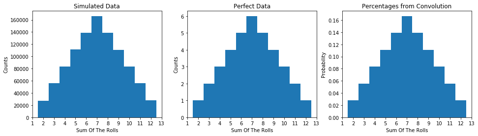

```python
fig, ax = plt.subplots(1,3,figsize=(16,4))

ax[0].set_title('Simulated Data')
ax[0].set_ylabel('Counts')
ax[0].set_xlabel('Sum Of The Rolls')
ax[0].hist(y,bins)
ax[0].set_xticks(bins +.5);
ax[0].set_xlim(1,13);

ax[1].set_title('Perfect Data')
ax[1].set_ylabel('Counts')
ax[1].set_xlabel('Sum Of The Rolls')
ax[1].hist(yperf,bins)
ax[1].set_xticks(bins +.5);
ax[1].set_xlim(1,13);

ax[2].set_title('Percentages from Convolution')
ax[2].set_ylabel('Probability')
ax[2].set_xlabel('Sum Of The Rolls')
ax[2].bar(np.arange(2,len(pdf2)+2),pdf2,align='center',width=1)
ax[2].set_xticks(bins +.5);
ax[2].set_xlim(1,13);
```

List of the probablilties of sums from np.convolutions

```python
for c, value in enumerate(pdf2):
    print('For the sum of the dice to equal {0:d} we get a probability of {1:f}'.format(c+2,value))
```

```
For the sum of the dice to equal 2 we get a probability of 0.027778
For the sum of the dice to equal 3 we get a probability of 0.055556
For the sum of the dice to equal 4 we get a probability of 0.083333
For the sum of the dice to equal 5 we get a probability of 0.111111
For the sum of the dice to equal 6 we get a probability of 0.138889
For the sum of the dice to equal 7 we get a probability of 0.166667
For the sum of the dice to equal 8 we get a probability of 0.138889
For the sum of the dice to equal 9 we get a probability of 0.111111
For the sum of the dice to equal 10 we get a probability of 0.083333
For the sum of the dice to equal 11 we get a probability of 0.055556
For the sum of the dice to equal 12 we get a probability of 0.027778
```

### Problem 3:

Mean and variation of the perfect data

```python
yperf.mean(),np.var(yperf)
```

```
(7.0, 5.833333333333333)
```

Writing out how to calculate the mean and variance of the sum with the pdf from the convolution function

$$\bar{x} = \sum x P_{sum}(x)$$

$$var \equiv \sigma^2 = \sum (x-\bar{x})^2 P_{sum}(x)$$

```python
mean1 = sum(np.arange(2,13) * (pdf2))
var1 = sum(((np.arange(2,13)-mean1)**2)*pdf2)
mean1,var1
```

```
(7.0, 5.833333333333334)
```

Mean and variation of the Simulated data

```python
y.mean(),np.var(y)
```

```
(7.001817, 5.845623698511)
```

### Problem 4:

```python
#4 dice
pdf4 = np.convolve(pdf1,pdf1, mode = "full")

#8 dice
pdf8 = np.convolve(pdf4,pdf4, mode = "full")

#10 dice
pdf10 = np.convolve(pdf8,pdf2, mode = "full")
len(pdf10)

#binning
bins2 = np.arange(0,60 +.1) - .1
```

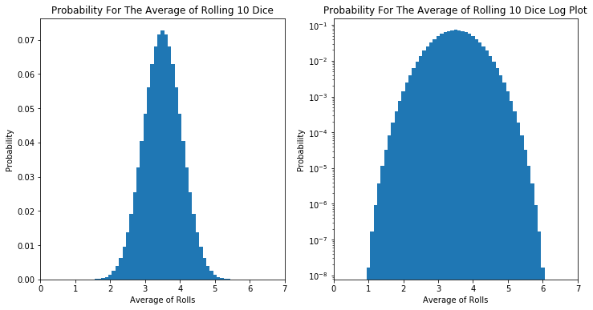

```python
fig,ax = plt.subplots(1,2,figsize=(12,6))

ax[0].set_title('Probability For The Average of Rolling 10 Dice')
ax[0].set_ylabel('Probability')
ax[0].set_xlabel('Average of Rolls')
ax[0].bar(np.linspace(1,(len(pdf10)+9)/10,51),pdf10,align='center',width=.1)
ax[0].set_xlim(0,7);

ax[1].set_title('Probability For The Average of Rolling 10 Dice Log Plot')
ax[1].set_ylabel('Probability')
ax[1].set_xlabel('Average of Rolls')
ax[1].bar(np.linspace(1,(len(pdf10)+9)/10,51),pdf10,align='center',width=.1)
ax[1].set_xlim(0,7);
ax[1].set_yscale('log')
```

This has aproached a Guassian distribution. Through inspection of the log plot of the probabilities the unique inverted parabola feature is very apparent. This arises from the Guassian distribution $ {\displaystyle {\frac {1}{\sqrt {2\pi \sigma ^{2}}}}e^{-{\frac {(x-\mu )^{2}}{2\sigma ^{2}}}}}$ so when you take the log of the pdf you get a function that is proportional to $-(x-\mu)^2$ which is a inverted parabola with a center at the mean of the distribution.

A more mathematically rigorous explaination is that the sum of the dice rolls is a binomial distribution with a probability of success equal to 1/6 for each side of the die, but as the number of dice being rolled increases the binomial distrubition begins to approximate the normal distribution as n gets large.

### Problem 5:

The convolution of two Gaussian distributions is a tedious thing to write out. A trick to making it quicker is to use the fact that $\mathcal{F}(f(x) ^* g(x)) = \mathcal{F}(f(x)) \cdot \mathcal{F}(g(x)) $. We know that the Fourier transform of a gaussian is just another gaussian. This means that... $$ \mathcal {F}^{-1}{\big \{}{\mathcal {F}}\{f_{X}\}\cdot {\mathcal {F}}\{f_{Y}\}{\big \}} ={\frac {1}{{\sqrt {2\pi }}\sigma _{Z}}}\exp \left[-{(z-(\mu _{X}+\mu _{Y}))^{2} \over 2\sigma _{Z}^{2}}\right]$$

Where $\sigma_Z = \sqrt{\sigma_X^2 + \sigma_Y^2}$